# Project 1

sbsambado

11/2/2021

## Title

The elephant in the room: delayed motherhood

## Executive Summary

## Introduction

The growth and health of babbies

## Methods

## Results

## Conclusions & Recommendations

## References

## Appendeix

total responses = 6851

```
## 'data.frame':    4 obs. of  7 variables:
##  $ age            : Factor w/ 2 levels "older","young": 2 2 1 1
##  $ smoker         : Factor w/ 2 levels "no","yes": 1 2 1 2
##  $ premature_died : num  50 9 41 4
##  $ premature_alive: num  315 40 147 11
##  $ full_died      : num  24 6 14 1
##  $ full_alive     : num  4012 459 1594 124
##  $ total          : num  4401 514 1796 140
```

### A) Are young mothers or molder mothers more likely to smoke?

**Answer:** Young mothers are more likely to smoke than older mothers. Comparing two proportions with the `prop.test` we can see that the proportion of young and old mothers that smoke are 0.105 and 0.0723, respectively. We can reject the null hypothesis is that the proportion of young smokers is equal to the proportion of old smokers with a p-value = 5.204e-05.

Table A. Age and smoking habits

|  | Smoker Yes | Smoker No |
| --- | --- | --- |
| Young | 514 | 4,401 |
| Older | 140 | 1,796 |

```
##
##  2-sample test for equality of proportions with continuity correction
##
## data:  c(514, 140) out of c(4915, 1936)
## X-squared = 16.372, df = 1, p-value = 5.204e-05
## alternative hypothesis: two.sided
## 95 percent confidence interval:
##  0.01754066 0.04698689
## sample estimates:
##     prop 1     prop 2
## 0.10457782 0.07231405
```

Table A. Age and smoking habits

|  | Smoker Yes | Smoker No |
| --- | --- | --- |
| Young | 514 | 4,401 |
| Older | 140 | 1,796 |

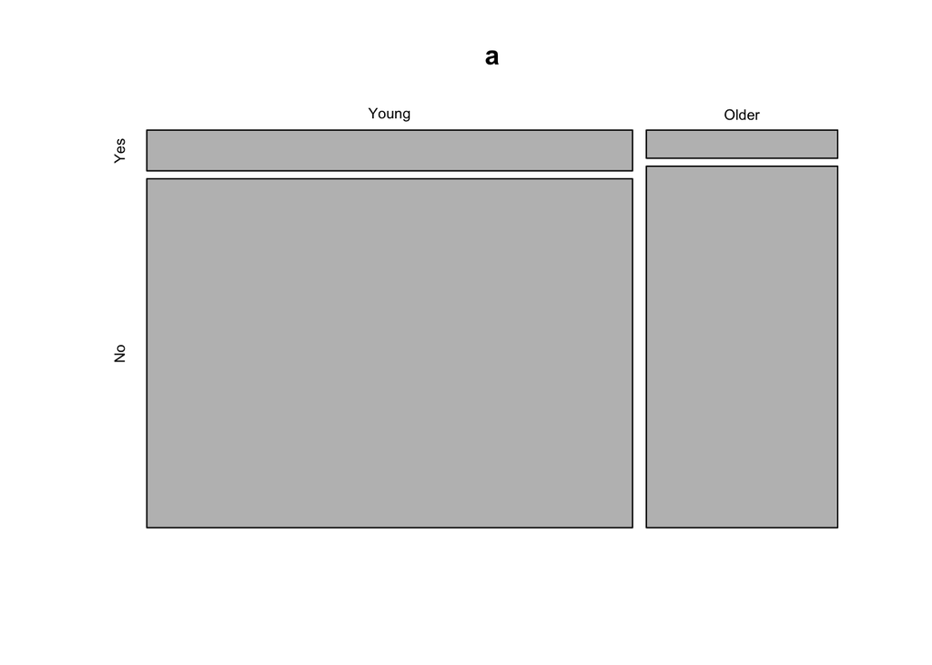

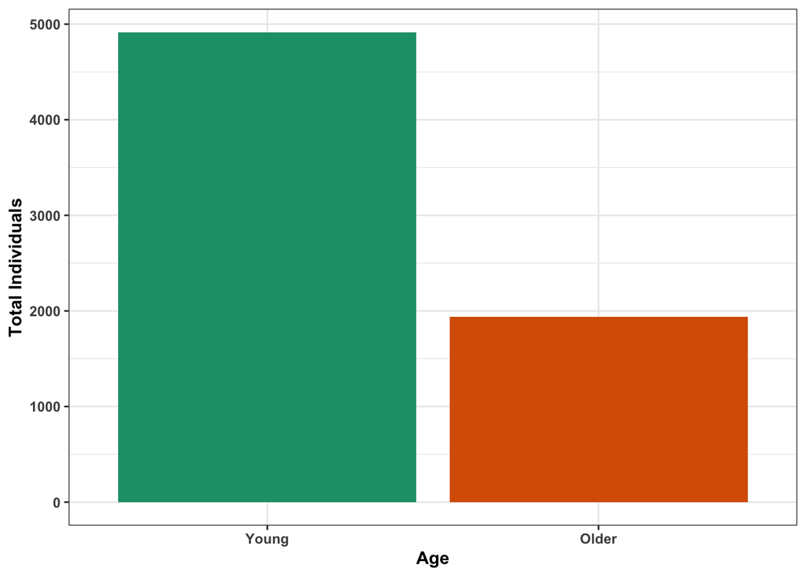

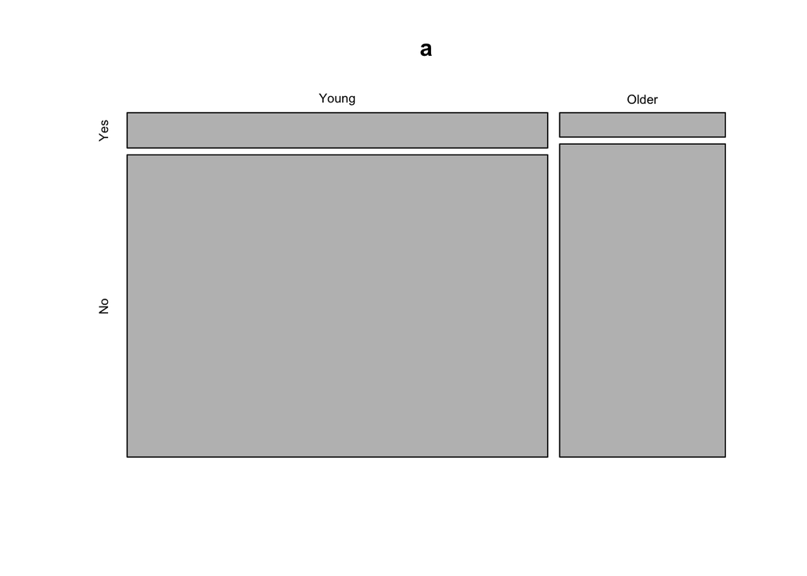

### B) Are smokers more likely to have premature babies? Are older mothers more likely to have premature babies?

Smoking habbit and premature baby are independent of each other (X-squared = 0.43665, df = 1, p-value = 0.5087) but Age and premature baby are not independent of each other (X-squared = 6.9592, df = 1, p-value = 0.008339)

```
##
##  Pearson's Chi-squared test with Yates' continuity correction
##
## data:  x
## X-squared = 0.43665, df = 1, p-value = 0.5087
```

```
##
##  Pearson's Chi-squared test with Yates' continuity correction
##
## data:  x
## X-squared = 6.9592, df = 1, p-value = 0.008339
```

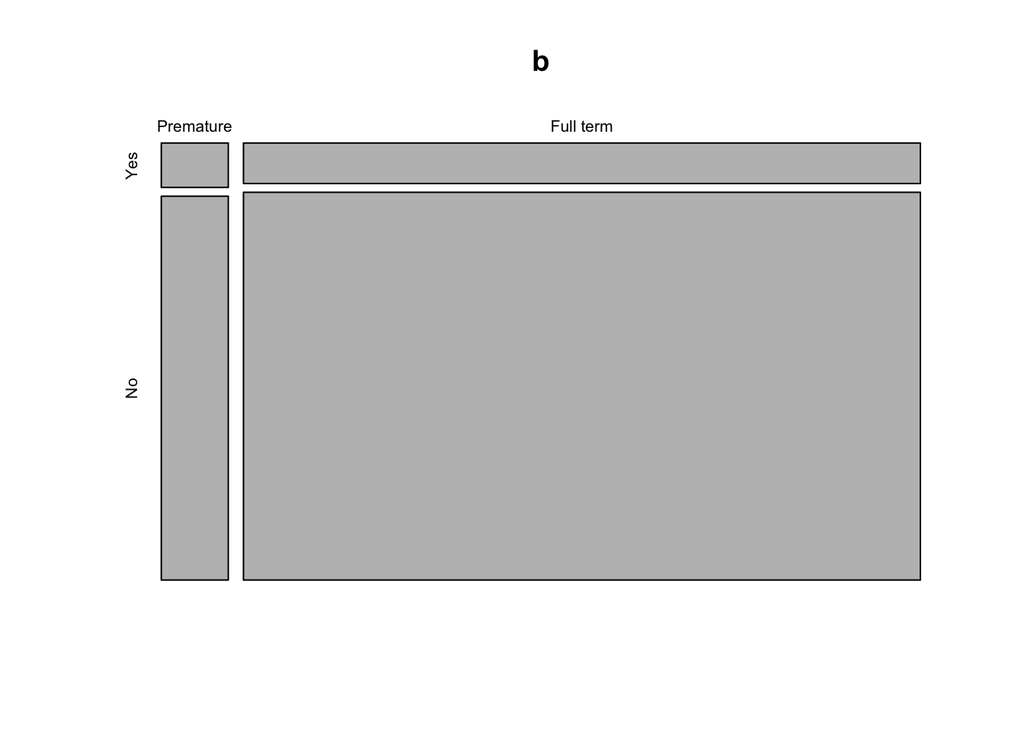

Table B1. Gestation and smoking habits

|  | Smoker Yes | Smoker No |
| --- | --- | --- |
| Premature | 64 | 553 |
| Full term | 590 | 5,644 |

Table B2. Gestation and Age

|  | Gestation Premature | Gestation Full term |
| --- | --- | --- |
| Old | 203 | 1,733 |
| Younger | 414 | 4,501 |

### C) Are smokers more likely to have babies who died in the 1st year? Are older mothers more likely to have babies who died in the 1st year?

old: 60/1936 = 0.0309 died young: 89/4915= 0.018 died

```
##
##  Pearson's Chi-squared test with Yates' continuity correction
##
## data:  x
## X-squared = 2.212, df = 1, p-value = 0.1369
```

```
##
##  Pearson's Chi-squared test with Yates' continuity correction
##
## data:  x
## X-squared = 10.239, df = 1, p-value = 0.001375
```

Table C1. Baby survival and smoking habits

|  | Smoker Yes | Smoker No |
| --- | --- | --- |
| Dead | 20 | 129 |
| Alive | 634 | 6,068 |

Table C2. Baby survival and age

|  | Baby Survival Dead | Baby Survival Alive |
| --- | --- | --- |
| Old | 60 | 1,876 |
| Young | 89 | 4,826 |

### D) How do age and smoking habits affect survival? How does age and smoking habits affect gestational age?

```
##
## Call:
## glm(formula = success ~ age + smoke, family = binomial(link = "logit"),
##     data = d_uncount)
##
## Deviance Residuals:
##     Min       1Q   Median       3Q      Max
## -2.6870   0.2342   0.2342   0.2342   2.1386
##
## Coefficients:
##             Estimate Std. Error z value Pr(>|z|)
## (Intercept)  -2.1796     0.3430  -6.355 2.09e-10 ***
## ageyoung      0.4931     0.3579   1.378    0.168
## smokeyes      5.2692     0.3314  15.901  < 2e-16 ***
## ---
## Signif. codes:  0 '***' 0.001 '**' 0.01 '*' 0.05 '.' 0.1 ' ' 1
##
## (Dispersion parameter for binomial family taken to be 1)
##
##     Null deviance: 770.42  on 802  degrees of freedom
## Residual deviance: 294.52  on 800  degrees of freedom
## AIC: 300.52
##
## Number of Fisher Scoring iterations: 6
```

```
## count
##   803
```

Table D. Baby survival (surives = 1, dies = 0)

[output not shown]